# Jokes Recommendation

### Accuracy Measures

For our final chosen algorithms, let’s examine how our prediction error, as measured by MAE, changes with training size. Instead of using training size explicitly, we use proportion of the data trained on. Since the total size of the limited dataset is 10,000, a portion of .2 would mean that we trained the model on 2,000 users and tested it on the other 8,000.

```r
sample_test <- function(x, n = 15){
  ind <- sample(1:length(x[!is.na(x)]), n)
  x[!is.na(x)][-ind] <- NA
  return(x)
}

sample_prop <- c(.001, .005, seq(.01, .1, by = .01), seq(.15, .5, by = .05))
train_eval <- function(proportion, given = 15, method, param, data = ratings){
  split <- train_test_split(data, train_proportion = proportion)
  train_data <- split$train_data
  training_sparse <- as(as.matrix(train_data), 'realRatingMatrix')
  ibcf_pearson <- Recommender(data = training_sparse, method = method, parameter = param)

  test_data <- split$test_data
  test_data_sparse <- as(as.matrix(test_data), 'realRatingMatrix')
  test_data_sample <- apply(test_data, 1, sample_test, n = given)
  test_data_sample  <- as.data.frame(t(test_data_sample))
  test_sample_sparse <- as(as.matrix(test_data_sample), 'realRatingMatrix')

  predicted_ratings <- predict(ibcf_pearson, test_sample_sparse, type = 'ratings')
  err_metrics <- calcPredictionAccuracy(x = predicted_ratings, data = test_data_sparse)
  return(err_metrics)
}

#Item-based Pearson
size_err_IB <- lapply(sample_prop, train_eval, method = "IBCF", param = list(k = 30, method = 'pearson'))
size_err_IB <- do.call(rbind.data.frame, size_err_IB)
names(size_err_IB) <- c('RMSE','MSE','MAE')
size_err_IB$train_prop <- sample_prop
size_err_IB$model <- "Pearson Item-Based CF"

#User-based Cosine
size_err_UB <- lapply(sample_prop, train_eval, method = "UBCF", param = list(nn = 100, method = 'cosine'))
size_err_UB <- do.call(rbind.data.frame, size_err_UB)
names(size_err_UB) <- c('RMSE','MSE','MAE')
size_err_UB$train_prop <- sample_prop
size_err_UB$model <- "Cosine User-Based CF"

#Random
size_err_rand <- lapply(sample_prop, train_eval, method = "RANDOM", param = NULL)
size_err_rand <- do.call(rbind.data.frame, size_err_rand)
names(size_err_rand) <- c('RMSE','MSE','MAE')
size_err_rand$train_prop <- sample_prop
size_err_rand$model <- "Random"

#SVD
#Insert code here

size_err_all <- rbind(size_err_IB, size_err_UB, size_err_rand)
```

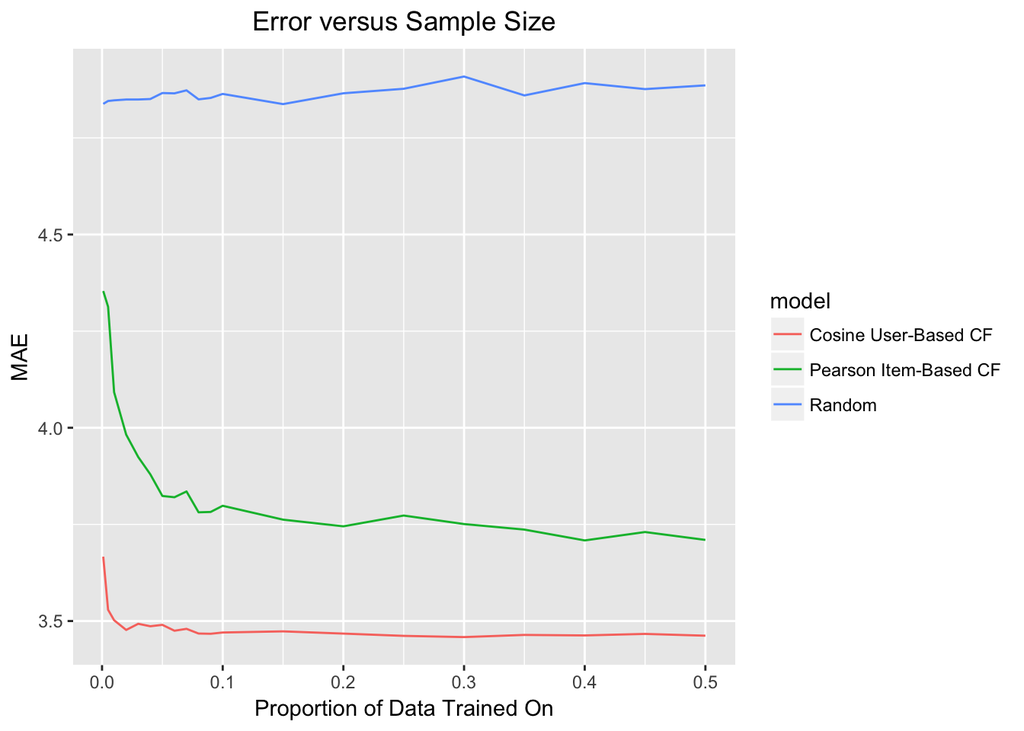

```r
ggplot(size_err_all, aes(x = train_prop, y = MAE)) + geom_line(aes(color = model)) +
  ggtitle("Error versus Sample Size") +
  xlab("Proportion of Data Trained On") +
  theme(plot.title = element_text(hjust = 0.5))
```

The plot indicates that for both models, we only need to train on 10-20% of the users before MAE stabilizes.

An additional question to consider is the following: how many ratings for a new user do we need in order to make accurate predictions? In the above analyses, we provided 15 ratings per test user, but might we get better results if we increased this number? To answer this question, let’s plot prediction error (MAE) as a function of number of ratings given per user in the test set. Intuitively, this number must be less than the number of ratings supplied by the user for which we have the least information (here, it is 36). Otherwise, we would be unable to test our predictions!

```r
min_ratings <- min(apply(ratings, 1, function(x){length(which(!is.na(x)==TRUE))}))
max_keep <- 5*floor(min_ratings/5)
keep <- c(3, seq(5,max_keep,5))

#Item-based Pearson
keep_err_IB <- lapply(keep, train_eval, proportion = .2, method = "IBCF", param = list(k = 30, method = 'pearson'))
keep_err_IB <- do.call(rbind.data.frame, keep_err_IB)
names(keep_err_IB) <- c('RMSE','MSE','MAE')
keep_err_IB$ratings_given <- keep
keep_err_IB$model <- "Pearson Item-Based CF"

#User-based Cosine
keep_err_UB <- lapply(keep, train_eval, proportion = .2, method = "UBCF", param = list(nn = 100, method = 'cosine'))
keep_err_UB <- do.call(rbind.data.frame, keep_err_UB)
names(keep_err_UB) <- c('RMSE','MSE','MAE')
keep_err_UB$ratings_given <- keep
keep_err_UB$model <- "Cosine User-Based CF"

#Random
keep_err_rand <- lapply(keep, train_eval, proportion = .2, method = "RANDOM", param = NULL)
keep_err_rand <- do.call(rbind.data.frame, keep_err_rand)
names(keep_err_rand) <- c('RMSE','MSE','MAE')
keep_err_rand$ratings_given <- keep
keep_err_rand$model <- "Random"

#add code for keep_err_SVD

keep_err_all <- rbind(keep_err_IB, keep_err_UB, keep_err_rand)
```

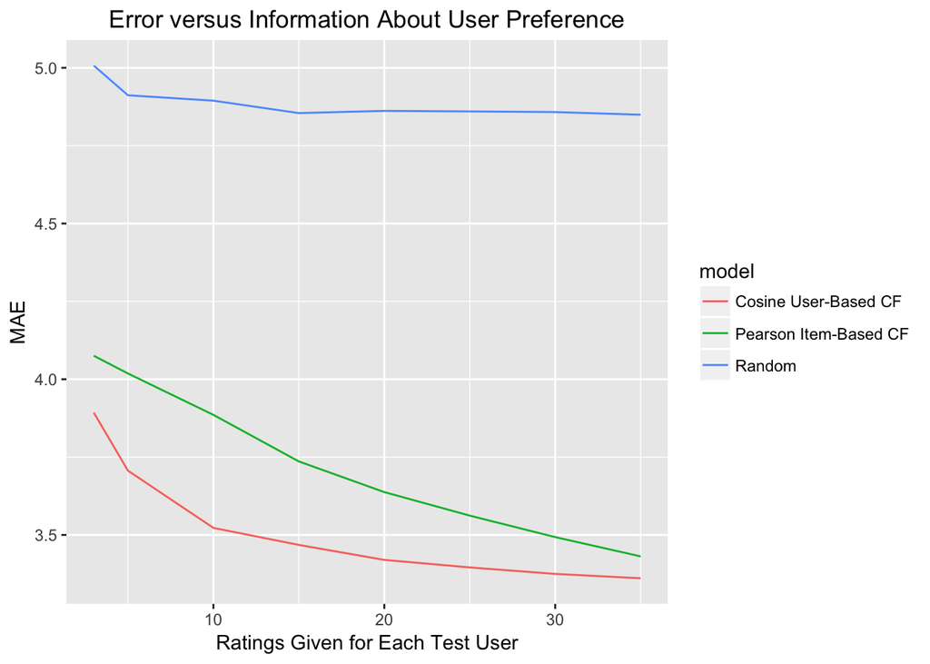

```r
ggplot(keep_err_all, aes(x = ratings_given, y = MAE)) + geom_line(aes(color = model)) +
   ggtitle("Error versus Information About User Preference") +
   xlab("Ratings Given for Each Test User") +
   theme(plot.title = element_text(hjust = 0.5))
```

The plot shows that the MAE of our collaborative filtering models do not level out as the number of items given approaches 35, which implies that we need more information about a user’s sense of humor (i.e. more joke ratings) to generate more accurate predictions. In order to obtain this information, we will train and test one final set of models on the of subset users for which we have complete information (that is 100 joke ratings). This subset has 2899 users. We will train on 80% of these users and test on the other 20%.

```r
ratings_full <- ratings[complete.cases(ratings), ]
keep2 <- seq(5,95,5)
keep2_err_IB <- lapply(keep2, train_eval, data = ratings_full, proportion = .8, method = "IBCF", param = list(k = 30, method = 'pearson'))
keep2_err_IB <- do.call(rbind.data.frame, keep2_err_IB)
names(keep2_err_IB) <- c('RMSE','MSE','MAE')
keep2_err_IB$model <- "Pearson Item-Based CF"

keep2_err_UB <- lapply(keep2, train_eval, data = ratings_full, proportion = .8, method = "UBCF", param = list(nn = 100, method = 'cosine'))
keep2_err_UB <- do.call(rbind.data.frame, keep2_err_UB)
names(keep2_err_UB) <- c('RMSE','MSE','MAE')
keep2_err_UB$model <- "Cosine User-Based CF"

keep2_err_all <- rbind(keep2_err_IB, keep2_err_UB)
keep2_err_all$ratings_given <- keep2
```

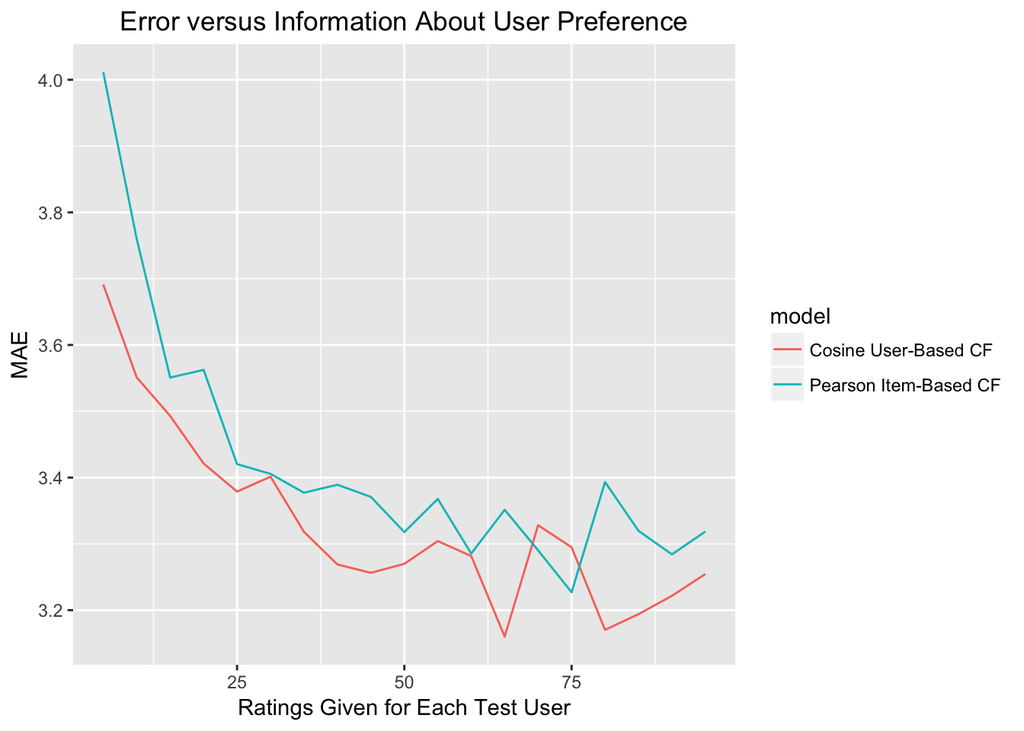

```r
ggplot(keep2_err_all, aes(x = ratings_given, y = MAE)) + geom_line(aes(color = model)) +
  ggtitle("Error versus Information About User Preference") +
  xlab("Ratings Given for Each Test User") +
  theme(plot.title = element_text(hjust = 0.5))
```